# TBS for treating depression in elderly

Matthias Lüthi

2025-07-21

# 1 Tables

## 1.1 Table 1

| Characteristic | Active TBS N = 54 | Sham TBS N = 54 | P |
| --- | --- | --- | --- |
| Demographics |  |  |  |
| Gender (% Female) | 36 (67) | 41 (76) | 0.4 |
| Age, y | 66.9 ± 4.8 | 66.6 ± 6.9 | 0.81 |
| White - no. (%) | 48 (89) | 40 (74) | 0.08 |
| Years of education - mean (SD) | 12.9 ± 4.5; n=53 | 13 ± 5.2; n=53 | 0.9 |
| At least 3 minimum wages - no. (%) | 29 (54) | 28 (53); n=53 | >0.99 |
| Retired - no. (%) | 35 (65) | 32 (59) | 0.69 |
| Relationship Status (% Partnered) | 24 (44) | 18 (33) | 0.32 |
| Physical Activity (% Active) | 11 (21); n=53 | 9 (17); n=53 | 0.8 |
| Clinical characteristics |  |  |  |
| Hypertension - no. (%) | 22 (41) | 25 (47); n=53 | 0.64 |
| Hypothyroidism - no. (%) | 11 (20) | 10 (19); n=53 | >0.99 |
| Duration of current episode, months - mean (SD) | 37.9 ± 40.7; n=37 | 27 ± 30.7; n=36 | 0.2 |
| Refractory depression - no. (%) | 21 (47); n=45 | 22 (49); n=45 | >0.99 |
| Currently in psychotherapy - no. (%) | 8 (16); n=50 | 13 (27); n=49 | 0.3 |
| Current benzodiazepine use - no. (%) | 6 (18); n=33 | 11 (33); n=33 | 0.26 |
| No. failed AD trials in lifetime - median (IQR) | 2 (1-4); n=29 | 2 (1-3); n=34 | 0.92 |
| Onset age of MDD, years - mean (SD) | 42.4 ± 15.5; n=37 | 43.1 ± 18.4; n=36 | 0.85 |
| No. previous depressive episodes - median (IQR) | 3 (1-4); n=36 | 3 (2-4); n=36 | 0.72 |
| Scales at baseline |  |  |  |
| Hamilton Depression Rating Scale (HDRS-17) | 20.9 ± 3.4 | 22.1 ± 3.8 | 0.1 |
| Montgomery-Asberg Depression Rating Scale (MADRS) | 27.1 ± 6.3 | 28 ± 6.4 | 0.48 |
| Geriatric Depression Scale (GDS) | 8.6 ± 1.7 | 8.8 ± 1.6 | 0.38 |
| Mania (YMRS) | 1.7 ± 1.6 | 1.6 ± 1.4 | 0.8 |
| Positive affect (PANAS) | 25.7 ± 5.6 | 24.9 ± 4.5 | 0.45 |
| Negative affect (PANAS) | 24.1 ± 5.8 | 23.3 ± 5.5 | 0.44 |
| Clinical Global Impression (CGI) | 4.2 ± 0.9 | 4.4 ± 0.9 | 0.47 |
| Cumulative Illness (CIRS-G) | 4.2 ± 3.1 | 3.6 ± 2.8 | 0.3 |

*Note:* (*) indicates that data from the HERAH system is missing (33 of 108 patients). There were no cases of hyperthyroidism.

## 1.2 Scale scores across time

## 1.3 Response & Remission

| Group | Type | Week 1 | Week 2 | Week 4 | Week 6 | Week 8 | Week 12 |
| --- | --- | --- | --- | --- | --- | --- | --- |
| Active TBS | Response - no. (%) | 6 (11) | 11 (20) | 14 (28) | 19 (39) | 24 (50) | 25 (52) |
| Active TBS | Remission - no. (%) | 1 (2) | 3 (6) | 6 (12) | 8 (16) | 15 (31) | 16 (33) |
| Sham TBS | Response - no. (%) | 4 (8) | 6 (12) | 7 (15) | 12 (24) | 16 (36) | 13 (29) |
| Sham TBS | Remission - no. (%) | 4 (8) | 2 (4) | 1 (2) | 4 (8) | 8 (18) | 9 (20) |

## 1.4 Hamilton Depression Rating Scale (HDRS) score reductions

```
## # A tibble: 2 × 5
##   condition_rev `mean(diff_hdrs_6, na.rm = TRUE)` sd(diff_hdrs_6, na.rm = TRUE…¹
##   <fct>                                     <dbl>                          <dbl>
## 1 Active TBS                                 8.65                           6.24
## 2 Sham TBS                                   7                              5.12
## # ℹ abbreviated name: ¹`sd(diff_hdrs_6, na.rm = TRUE)`
## # ℹ 2 more variables: `mean(diff_hdrs_12, na.rm = TRUE)` <dbl>,
## #   `sd(diff_hdrs_12, na.rm = TRUE)` <dbl>
```

# 2 Figures

## 2.1 Primary and secondary outcomes

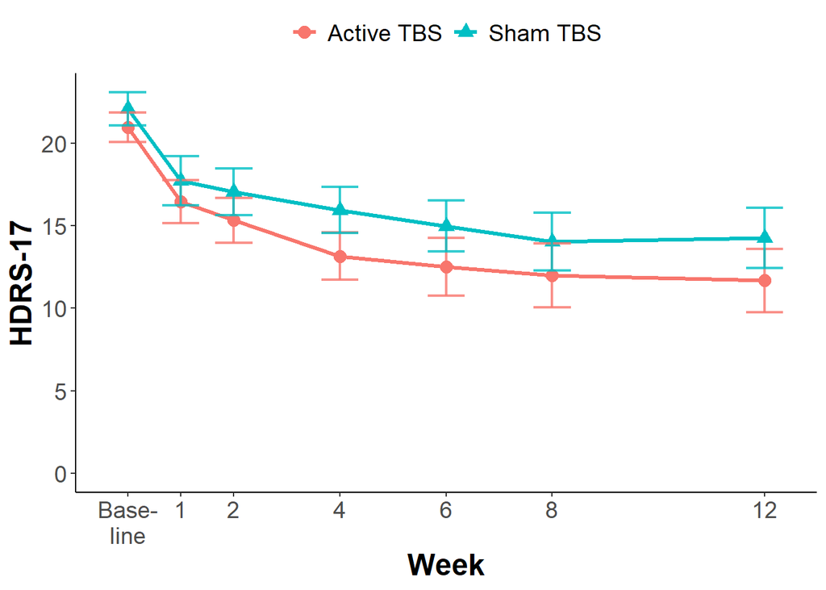

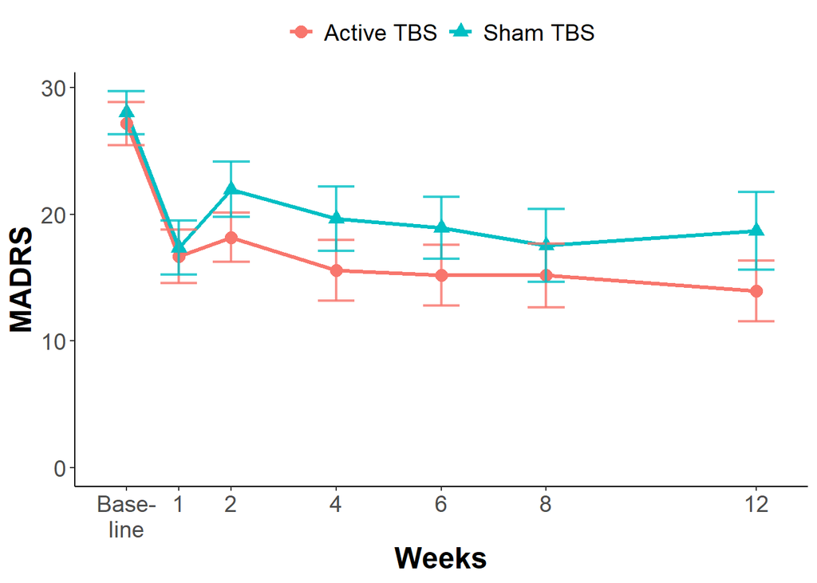

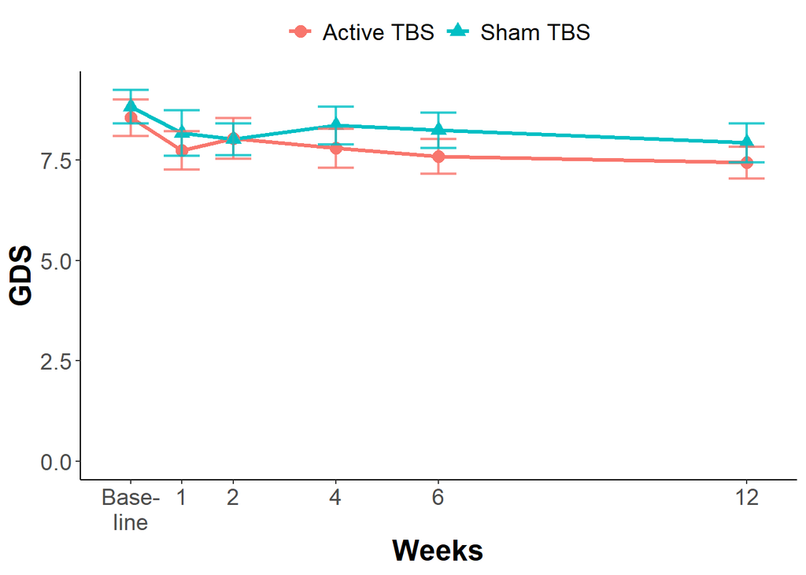

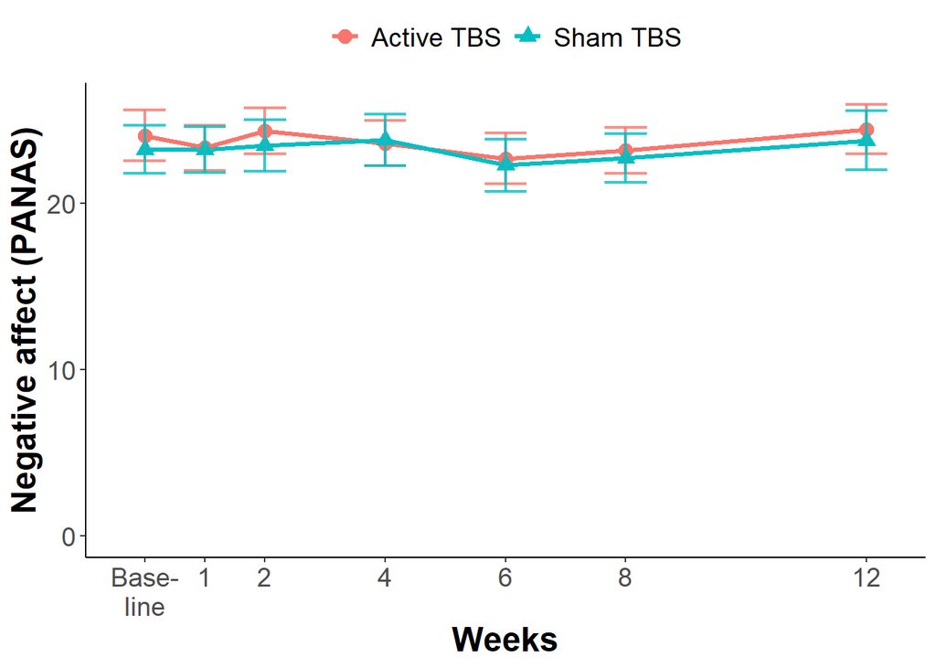

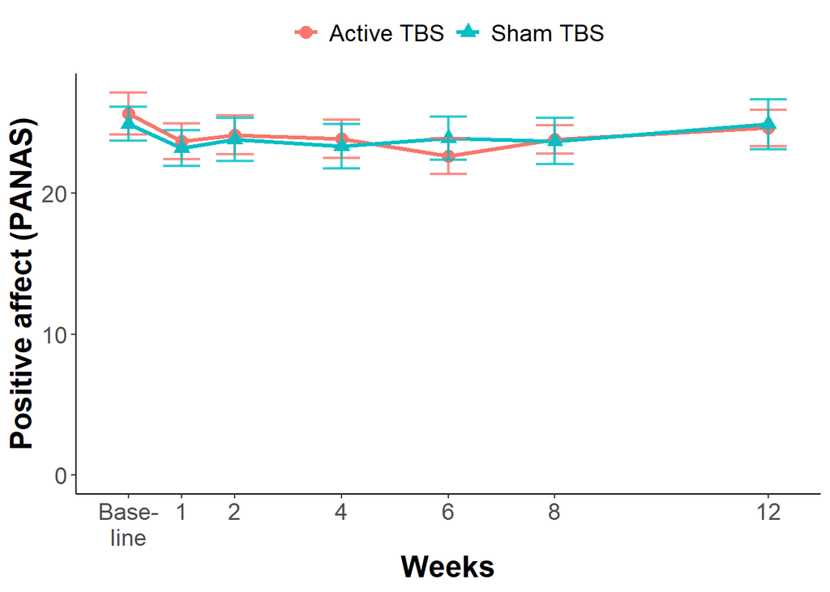

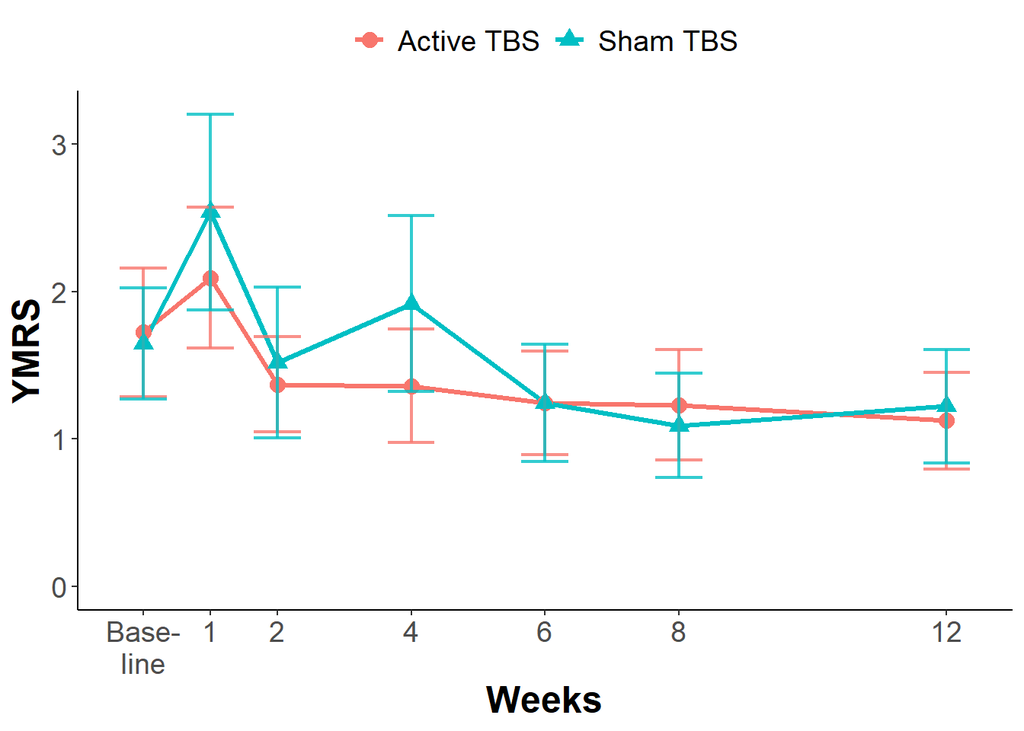

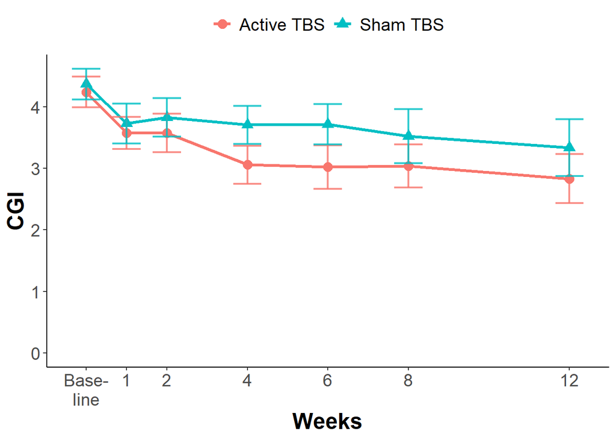

## 2.2 Alternative figures for main outcome

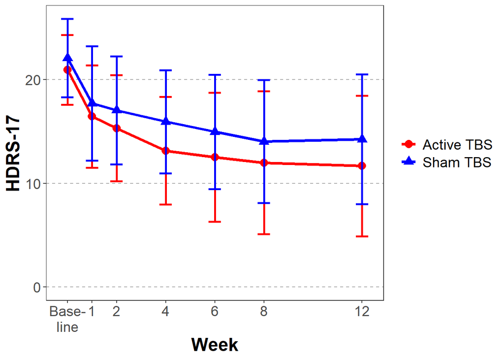

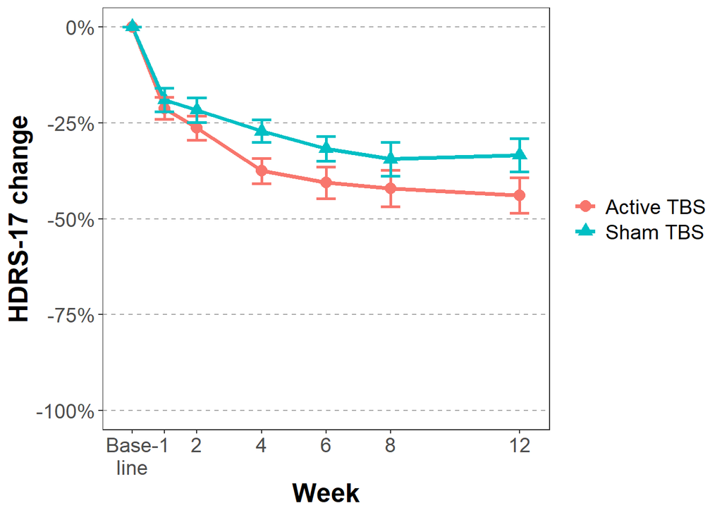

## 2.3 Response and Remission

| Condition | Type | Baseline | Week 1 | Week 2 | Week 4 | Week 6 | Week 8 | Week 12 |
| --- | --- | --- | --- | --- | --- | --- | --- | --- |
| Active TBS | HDRS remission - no. (%) | 0 (0) | 1 (2) | 3 (6) | 6 (12) | 8 (16) | 15 (31) | 16 (33) |
| Sham TBS | HDRS remission - no. (%) | 0 (0) | 4 (8) | 2 (4) | 1 (2) | 4 (8) | 8 (18) | 9 (20) |
| Active TBS | HDRS response - no. (%) | 0 (0) | 6 (11) | 11 (20) | 14 (28) | 19 (39) | 24 (50) | 25 (52) |
| Sham TBS | HDRS response - no. (%) | 0 (0) | 4 (8) | 6 (12) | 7 (15) | 12 (24) | 16 (36) | 13 (29) |
| Active TBS | MADRS remission - no. (%) | 1 (2) | 12 (22) | 7 (13) | 18 (36) | 14 (29) | 16 (33) | 22 (46) |
| Sham TBS | MADRS remission - no. (%) | 0 (0) | 8 (15) | 4 (8) | 8 (17) | 10 (20) | 11 (25) | 12 (27) |
| Active TBS | MADRS response - no. (%) | 0 (0) | 21 (39) | 14 (26) | 22 (44) | 23 (47) | 23 (48) | 27 (56) |
| Sham TBS | MADRS response - no. (%) | 0 (0) | 20 (38) | 8 (15) | 12 (25) | 18 (37) | 18 (41) | 13 (29) |

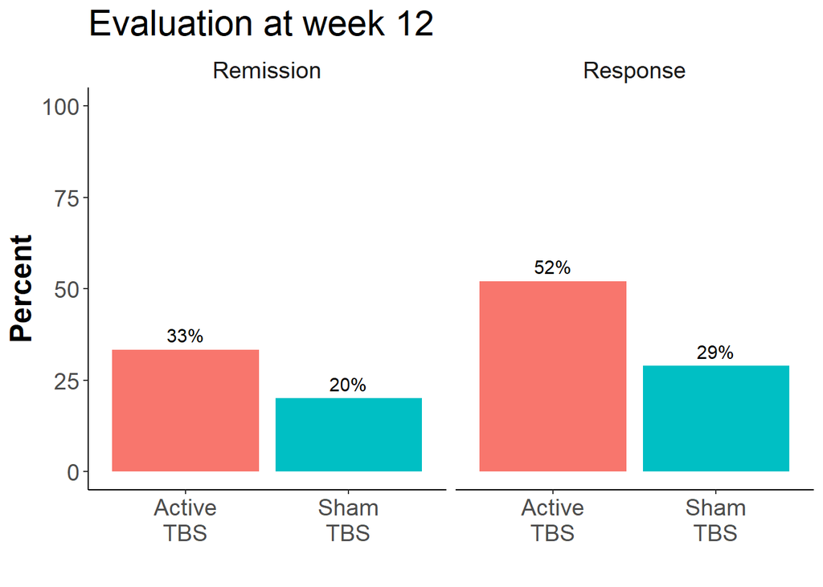

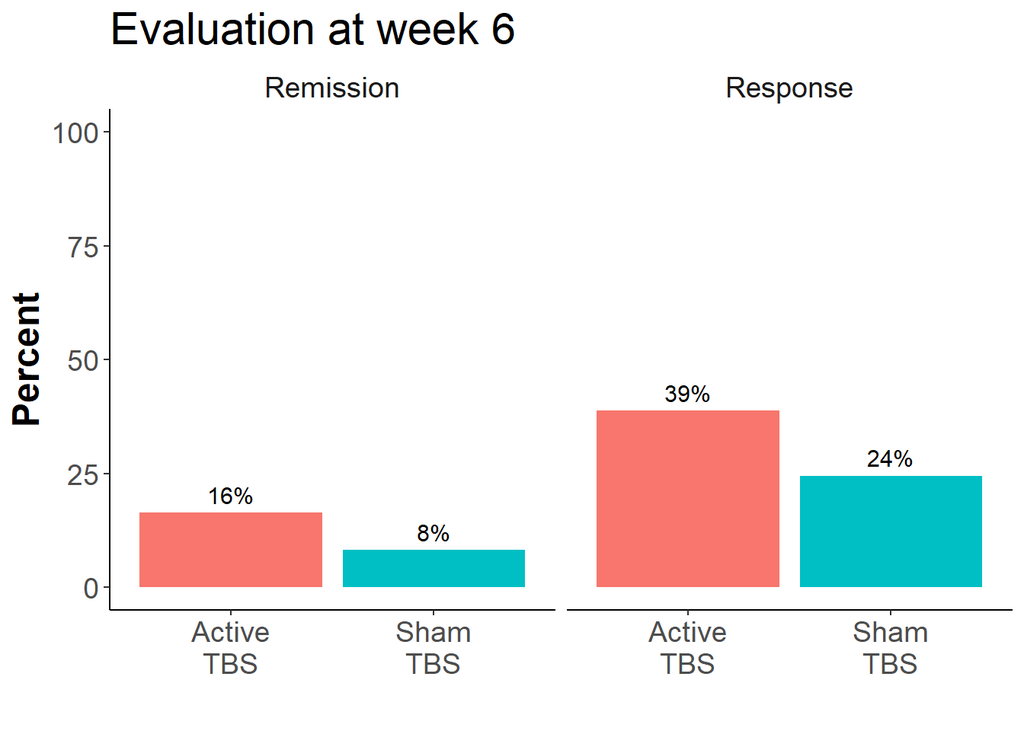

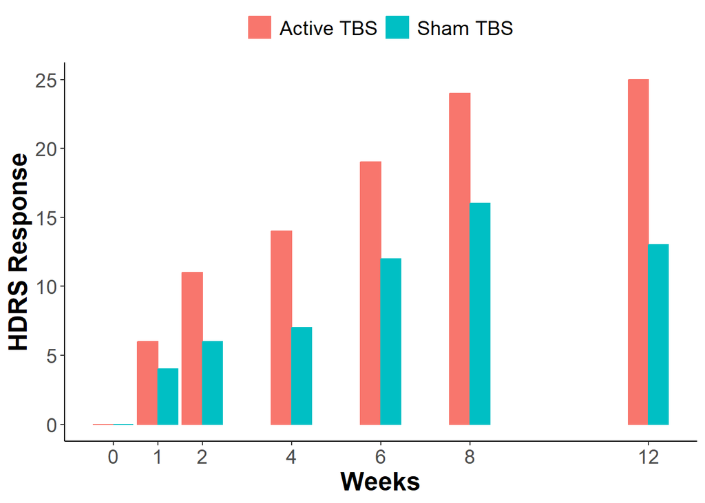

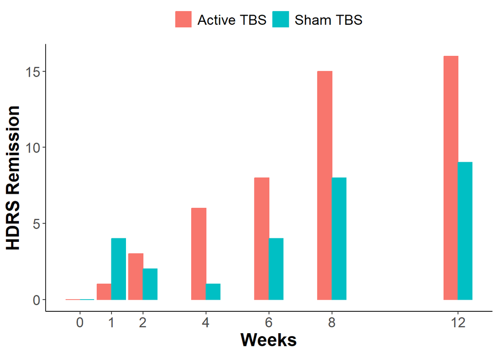

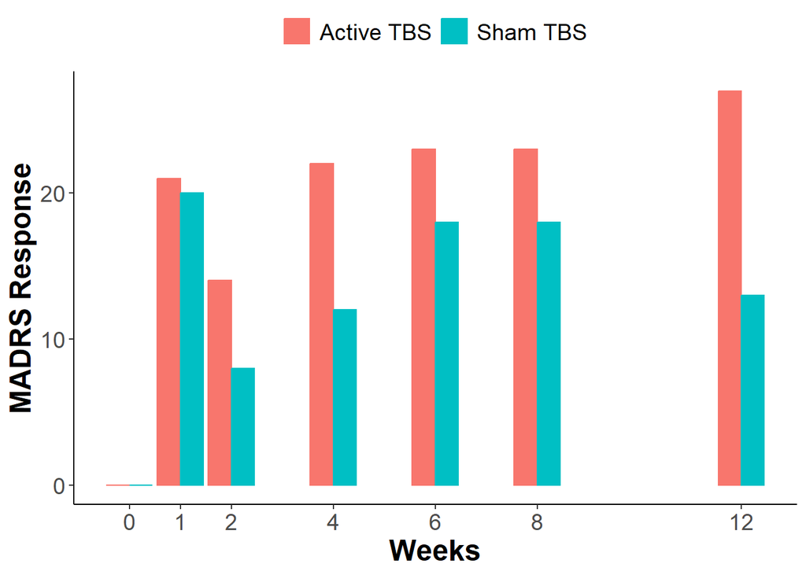

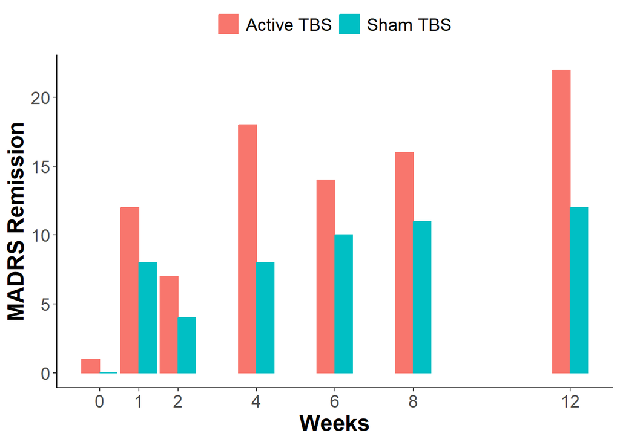

MADRS response and remission rates reflect the temporary drop in scores at week 1.

# 3 Antidepressive effects of treatment

## 3.1 Linear mixed models

```
## Linear mixed model fit by REML. t-tests use Satterthwaite's method [
## lmerModLmerTest]
## Formula: hdrs_total ~ condition * time_log + (1 | subject)
##    Data: dss
##
## REML criterion at convergence: 4137.5
##
## Scaled residuals:
##     Min      1Q  Median      3Q     Max
## -2.9720 -0.5970 -0.0486  0.5606  3.8498
##
## Random effects:
##  Groups   Name        Variance Std.Dev.
##  subject  (Intercept) 13.85    3.721
##  Residual             16.16    4.020
## Number of obs: 701, groups:  subject, 108
##
## Fixed effects:
##                              Estimate Std. Error       df t value Pr(>|t|)
## (Intercept)                   20.8514     0.6582 207.6871  31.677   <2e-16 ***
## conditionActive TBS           -1.1019     0.9288 206.2149  -1.186   0.2368
## time_log                      -2.8662     0.2633 606.2825 -10.887   <2e-16 ***
## conditionActive TBS:time_log  -0.7424     0.3687 604.6063  -2.014   0.0445 *
## ---
## Signif. codes:  0 '***' 0.001 '**' 0.01 '*' 0.05 '.' 0.1 ' ' 1
##
## Correlation of Fixed Effects:
##             (Intr) cnATBS tim_lg
## cndtnActTBS -0.709
## time_log    -0.539  0.382
## cndtnATBS:_  0.385 -0.540 -0.714
```

```
##   effect group                         term   estimate std.error  statistic
## 1  fixed  <NA>                  (Intercept) 20.8514328 0.6582475  31.677194
## 2  fixed  <NA>          conditionActive TBS -1.1019010 0.9287881  -1.186386
## 3  fixed  <NA>                     time_log -2.8661628 0.2632713 -10.886729
## 4  fixed  <NA> conditionActive TBS:time_log -0.7423533 0.3686863  -2.013509
##         df      p.value          d   CI     CI_low     CI_high
## 1 207.6871 1.826499e-81  4.3961438 0.95  3.8919460  4.89687156
## 2 206.2149 2.368351e-01 -0.1652326 0.95 -0.4384699  0.10840369
## 3 606.2825 2.471250e-25 -0.8842802 0.95 -1.0507414 -0.71715137
## 4 604.6063 4.450369e-02 -0.1637749 0.95 -0.3233939 -0.00402086
```

A linear mixed-effects model was used to investigate if treatment was effective. Time was assumed to be linear on a natural logarithmic scale. HDRS-17 was the outcome, group and time were included as interacting fixed effects, and subject as random-intercept effect. Results showed a reduction in HDRS-17 scores across time, independent of group (t(606) = -10.89, P < .001). There was a a significant interaction of group and time (t(604) = -2.01, P = 0.045). This indicates that active TBS treatment was effective in reducing depressive symptoms.

The following tables show the interaction tests for all outcomes at different endpoints (week 6 or 12).

Results until week 6

| Scale | Estimate | SE | t | DF | P | Cohen's d |
| --- | --- | --- | --- | --- | --- | --- |
| HDRS | -0.90 | 0.47 | -1.89 | 412.30 | 0.059 | -0.36 [-0.74, 0.01] |
| MADRS | -1.97 | 0.83 | -2.37 | 412.87 | 0.018 | -0.45 [-0.83, -0.08] |
| GDS | -0.20 | 0.18 | -1.08 | 413.27 | 0.280 | -0.21 [-0.58, 0.17] |
| PANAS negative | -0.62 | 0.50 | -1.24 | 412.11 | 0.216 | -0.24 [-0.61, 0.14] |
| PANAS positive | -1.07 | 0.49 | -2.20 | 412.41 | 0.029 | -0.42 [-0.8, -0.04] |
| YMRS | -0.17 | 0.19 | -0.90 | 404.08 | 0.367 | -0.17 [-0.55, 0.2] |
| CGI1 | -0.32 | 0.12 | -2.73 | 415.52 | 0.007 | -0.52 [-0.9, -0.15] |

Results until week 12

| Scale | Estimate | SE | t | DF | P | Cohen's d |
| --- | --- | --- | --- | --- | --- | --- |
| HDRS | -0.74 | 0.37 | -2.01 | 604.61 | 0.045 | -0.42 [-0.83, -0.01] |
| MADRS | -1.52 | 0.60 | -2.53 | 605.49 | 0.012 | -0.53 [-0.94, -0.12] |
| GDS | -0.12 | 0.13 | -0.94 | 606.78 | 0.348 | -0.2 [-0.6, 0.21] |
| PANAS negative | -0.32 | 0.34 | -0.92 | 602.59 | 0.358 | -0.19 [-0.6, 0.22] |
| PANAS positive | -0.63 | 0.34 | -1.88 | 603.47 | 0.060 | -0.39 [-0.8, 0.02] |
| YMRS | -0.05 | 0.12 | -0.37 | 594.46 | 0.708 | -0.08 [-0.49, 0.33] |
| CGI1 | -0.21 | 0.09 | -2.46 | 609.84 | 0.014 | -0.51 [-0.92, -0.1] |

## 3.2 Linear mixed models on per-protocol (PP) sample

```
## # A tibble: 7 × 2
##    time `sum(!is.na(hdrs_total))`
##   <int>                     <int>
## 1     0                       108
## 2     1                       106
## 3     2                       106
## 4     4                        98
## 5     6                        98
## 6     8                        92
## 7    12                        93
```

```
## # A tibble: 2 × 2
##   condition      N
##   <fct>      <int>
## 1 Sham TBS      46
## 2 Active TBS    50
```

Results until week 6

| Scale | Estimate | SE | t | DF | P | Cohen's d |
| --- | --- | --- | --- | --- | --- | --- |
| HDRS | -1.01 | 0.49 | -2.05 | 381.10 | 0.041 | -0.41 [-0.8, -0.02] |
| MADRS | -2.21 | 0.86 | -2.57 | 381.25 | 0.010 | -0.51 [-0.9, -0.12] |
| GDS | -0.19 | 0.19 | -0.99 | 381.15 | 0.322 | -0.2 [-0.59, 0.19] |
| PANAS negative | -0.61 | 0.52 | -1.17 | 381.11 | 0.241 | -0.23 [-0.62, 0.16] |
| PANAS positive | -1.14 | 0.50 | -2.27 | 381.20 | 0.024 | -0.45 [-0.84, -0.06] |
| YMRS | -0.19 | 0.18 | -1.09 | 381.38 | 0.276 | -0.22 [-0.61, 0.17] |
| CGI1 | -0.37 | 0.12 | -3.04 | 381.28 | 0.002 | -0.61 [-1, -0.21] |

Results until week 12

| Scale | Estimate | SE | t | DF | P | Cohen's d |
| --- | --- | --- | --- | --- | --- | --- |
| HDRS | -0.88 | 0.38 | -2.30 | 561.53 | 0.022 | -0.5 [-0.92, -0.07] |
| MADRS | -1.77 | 0.61 | -2.88 | 562.31 | 0.004 | -0.62 [-1.05, -0.2] |
| GDS | -0.13 | 0.13 | -1.01 | 563.12 | 0.314 | -0.22 [-0.64, 0.21] |
| PANAS negative | -0.25 | 0.35 | -0.70 | 561.60 | 0.487 | -0.15 [-0.57, 0.27] |
| PANAS positive | -0.69 | 0.35 | -2.01 | 561.91 | 0.045 | -0.43 [-0.86, -0.01] |
| YMRS | -0.08 | 0.12 | -0.71 | 563.97 | 0.477 | -0.15 [-0.58, 0.27] |
| CGI1 | -0.26 | 0.09 | -2.81 | 563.37 | 0.005 | -0.61 [-1.03, -0.18] |

## 3.3 LMM with Autoregressive covariance structure (HDRS only)

An autoregressive covariance structure is a type of within-subject correlation structure sometimes used in longitudinal data analysis. It assumes that the correlation between two observations within the same subject decreases as the time between the observations increases.

Until week 6:

```
## Linear mixed-effects model fit by REML
##   Data: filter(dss, time <= 6)
##        AIC      BIC    logLik
##   3030.334 3060.002 -1508.167
##
## Random effects:
##  Formula: ~1 | subject
##         (Intercept) Residual
## StdDev:    3.226422 4.073749
##
## Correlation Structure: Continuous AR(1)
##  Formula: ~time | subject
##  Parameter estimate(s):
##       Phi
## 0.3074477
## Fixed effects:  hdrs_total ~ condition * time
##                              Value Std.Error  DF  t-value p-value
## (Intercept)              20.491977 0.6364831 406 32.19564  0.0000
## conditionActive TBS      -1.277550 0.8990065 106 -1.42107  0.1582
## time                     -1.055508 0.1282522 406 -8.22994  0.0000
## conditionActive TBS:time -0.266200 0.1810900 406 -1.46999  0.1423
##  Correlation:
##                          (Intr) cnATBS time
## conditionActive TBS      -0.708
## time                     -0.550  0.389
## conditionActive TBS:time  0.390 -0.551 -0.708
##
## Standardized Within-Group Residuals:
##        Min         Q1        Med         Q3        Max
## -2.9567925 -0.5533191 -0.0632191  0.5697592  2.9494388
##
## Number of Observations: 516
## Number of Groups: 108
```

Until week 12:

```
## Linear mixed-effects model fit by REML
##   Data: dss
##        AIC      BIC    logLik
##   4202.237 4234.064 -2094.118
##
## Random effects:
##  Formula: ~1 | subject
##         (Intercept) Residual
## StdDev:     3.44291 4.703078
##
## Correlation Structure: Continuous AR(1)
##  Formula: ~time | subject
##  Parameter estimate(s):
##       Phi
## 0.5278129
## Fixed effects:  hdrs_total ~ condition * time
##                              Value Std.Error  DF   t-value p-value
## (Intercept)              19.571058 0.6965046 591 28.098963  0.0000
## conditionActive TBS      -1.552329 0.9831819 106 -1.578882  0.1173
## time                     -0.550677 0.0751718 591 -7.325574  0.0000
## conditionActive TBS:time -0.119470 0.1051168 591 -1.136548  0.2562
##  Correlation:
##                          (Intr) cnATBS time
## conditionActive TBS      -0.708
## time                     -0.560  0.397
## conditionActive TBS:time  0.401 -0.563 -0.715
##
## Standardized Within-Group Residuals:
##         Min          Q1         Med          Q3         Max
## -2.94323100 -0.62787867 -0.09888731  0.49768289  3.15279543
##
## Number of Observations: 701
## Number of Groups: 108
```

These models show no significant treatment effect (“conditionActive TBS:time”).

## 3.4 Delta analyses for HDRS

These are t-tests that compare the differences between baseline and endpoint for the 2 groups. They are a more traditional approach, but only don’t take all measures into account and have less power.

| Endpoint | t | DF | P |
| --- | --- | --- | --- |
| Week 2 | -0.71 | 103.40 | 0.477 |
| Week 6 | -1.43 | 92.50 | 0.155 |
| Week 12 | -1.34 | 90.97 | 0.184 |

## 3.5 Respone and Remission

### 3.5.1 Mixed logistic regressions

This approach considers all time points. Odds ratios indicate the change in chances for response or remission for one week of treatment.

Results until week 6

| Scale | Odds ratio | z | P |
| --- | --- | --- | --- |
| HDRS response | 1.38 | 0.57 | 0.569 |
| HDRS remission | 30.30 | 2.41 | 0.016 |
| MADRS response | 1.60 | 1.20 | 0.229 |
| MADRS remission | 1.20 | 0.39 | 0.699 |

Results until week 12

| Scale | Odds ratio | z | P |
| --- | --- | --- | --- |
| HDRS response | 1.55 | 1.08 | 0.278 |
| HDRS remission | 3.54 | 2.06 | 0.039 |
| MADRS response | 1.73 | 2.00 | 0.045 |
| MADRS remission | 1.22 | 0.60 | 0.548 |

### 3.5.2 Logistic regression

Logistic regression only considers data from the endpoint, it’s the more common approach for this type of analysis though.

Results for week 6

| Scale | Odds ratio | z | P |
| --- | --- | --- | --- |
| HDRS response | 1.95 | 1.51 | 0.131 |
| HDRS remission | 2.20 | 1.21 | 0.226 |
| MADRS response | 1.52 | 1.02 | 0.307 |
| MADRS remission | 1.56 | 0.94 | 0.349 |

Results for week 12

| Scale | Odds ratio | z | P |
| --- | --- | --- | --- |
| HDRS response | 2.68 | 2.25 | 0.025 |
| HDRS remission | 2.00 | 1.44 | 0.151 |
| MADRS response | 3.16 | 2.62 | 0.009 |
| MADRS remission | 2.33 | 1.90 | 0.057 |

# 4 Adverse events

t-Test for group difference in number of adverse events during the entire study”

```
## # A tibble: 1 × 7
##   statistic  t_df p_value alternative estimate lower_ci upper_ci
##       <dbl> <dbl>   <dbl> <chr>          <dbl>    <dbl>    <dbl>
## 1     -1.31  104.   0.192 two.sided    -0.0793   -0.199   0.0404
```

Logistic regression to test for group difference in number of adverse events for the final week

```
##
## Call:
## glm(formula = adverse_effects_w12 ~ condition, family = binomial,
##     data = dss_wide)
##
## Coefficients:
##                     Estimate Std. Error z value Pr(>|z|)
## (Intercept)          -1.8718     0.4385  -4.268 1.97e-05 ***
## conditionActive TBS   0.5635     0.5651   0.997    0.319
## ---
## Signif. codes:  0 '***' 0.001 '**' 0.01 '*' 0.05 '.' 0.1 ' ' 1
##
## (Dispersion parameter for binomial family taken to be 1)
##
##     Null deviance: 85.015  on 91  degrees of freedom
## Residual deviance: 83.995  on 90  degrees of freedom
##   (16 observations deleted due to missingness)
## AIC: 87.995
##
## Number of Fisher Scoring iterations: 4
```

# 5 Blinding

|  | Active TBS | Sham TBS | Chi-Square | P |
| --- | --- | --- | --- | --- |
| Patients |  |  |  |  |
| Guess active | 34 | 22 |  |  |
| Guess sham | 14 | 22 | 3.35 | 0.067 |
| Raters |  |  |  |  |
| Guess active | 25 | 21 |  |  |
| Guess sham | 23 | 23 | 0.04 | 0.835 |

# 6 Treatment response (HDRS) prediction

Predictors were evaluated for HDRS changes (deltas) from baseline to endpoint using linear regression and for HDRS response using logistic regression (generalized linear model). For each predictor, separate models were set up with the outcome referring to Week 6 or 12 as possible endpoint. Condition and predictor were included as interacting factors. A significant main effect of the predictor indicates that the predictor had an effect on HDRS changes/responses on the whole sample, independent of condition. A significant interaction of the predictor and condition indicates that the effectiveness of TBS depended on the predictor.

Variables not included because of no or only very few cases: - Hyperthyroidism (no case) - Stroke (“demarre”, only 3 cases)

## 6.1 Predicting HDRS change

| Predictor | Main effect Estimate | Main effect SE | Main effect t | Main effect P | Interaction Estimate | Interaction SE | Interaction t | Interaction P |
| --- | --- | --- | --- | --- | --- | --- | --- | --- |
| Change to week 6 |  |  |  |  |  |  |  |  |
| Gender | 0.00 | 1.91 | 0.00 | 1.000 | -1.11 | 2.64 | -0.42 | 0.674 |
| Age | 0.05 | 0.12 | 0.47 | 0.641 | -0.42 | 0.21 | -2.02 | 0.046 |
| Ethnicity (white/non-white) | -1.10 | 1.82 | -0.60 | 0.547 | 2.27 | 3.27 | 0.70 | 0.488 |
| Years of education | -0.13 | 0.16 | -0.84 | 0.402 | 0.37 | 0.25 | 1.47 | 0.145 |
| Unemployed (yes/no) | -1.83 | 2.35 | -0.78 | 0.437 | 1.12 | 3.81 | 0.29 | 0.769 |
| Wage (low/high) | 1.16 | 1.66 | 0.70 | 0.487 | -2.31 | 2.34 | -0.99 | 0.326 |
| Relationship (yes/no) | -1.53 | 1.72 | -0.89 | 0.376 | 2.39 | 2.39 | 1.00 | 0.320 |
| Phystical activity (low/high) | -0.64 | 2.38 | -0.27 | 0.787 | 0.86 | 3.16 | 0.27 | 0.787 |
| Hypertension | 1.05 | 1.68 | 0.63 | 0.531 | -0.53 | 2.37 | -0.22 | 0.824 |
| Duration of current episode | -0.02 | 0.03 | -0.61 | 0.545 | 0.03 | 0.04 | 0.74 | 0.464 |
| Refractory depression (yes/no) | -1.57 | 1.67 | -0.94 | 0.350 | 0.14 | 2.38 | 0.06 | 0.952 |
| Current benzodiazepine use (yes/no) | 0.95 | 2.33 | 0.41 | 0.685 | 1.59 | 3.61 | 0.44 | 0.661 |
| Currently in psychotherapy (yes/no) | -0.73 | 2.01 | -0.36 | 0.718 | 2.33 | 3.10 | 0.75 | 0.455 |
| No. failed AD trials in lifetime | 0.25 | 0.36 | 0.69 | 0.495 | -0.54 | 0.66 | -0.82 | 0.415 |
| Onset age of MDD * | 0.03 | 0.05 | 0.62 | 0.534 | -0.09 | 0.08 | -1.05 | 0.299 |
| No. previous depressive episodes * | -0.07 | 0.28 | -0.25 | 0.803 | -0.15 | 0.42 | -0.37 | 0.714 |
| Change to week 12 |  |  |  |  |  |  |  |  |
| Gender | 1.81 | 2.30 | 0.79 | 0.434 | -3.76 | 3.16 | -1.19 | 0.237 |
| Age | -0.10 | 0.14 | -0.73 | 0.468 | 0.11 | 0.26 | 0.42 | 0.675 |
| Ethnicity (white/non-white) | -1.92 | 2.29 | -0.84 | 0.403 | 6.29 | 3.94 | 1.60 | 0.114 |
| Years of education | -0.04 | 0.20 | -0.21 | 0.835 | 0.40 | 0.31 | 1.27 | 0.206 |
| Unemployed (yes/no) | -2.36 | 2.80 | -0.84 | 0.402 | -1.53 | 4.53 | -0.34 | 0.737 |
| Wage (low/high) | -0.39 | 2.05 | -0.19 | 0.851 | -2.37 | 2.84 | -0.83 | 0.407 |
| Relationship (yes/no) | -1.25 | 2.11 | -0.59 | 0.556 | 2.55 | 2.90 | 0.88 | 0.381 |
| Phystical activity (low/high) | -0.76 | 2.86 | -0.27 | 0.790 | -0.56 | 3.78 | -0.15 | 0.882 |
| Hypertension | -0.18 | 2.09 | -0.09 | 0.930 | -0.01 | 2.91 | 0.00 | 0.997 |
| Duration of current episode | -0.03 | 0.03 | -1.05 | 0.299 | 0.03 | 0.04 | 0.70 | 0.488 |
| Refractory depression (yes/no) | -3.56 | 2.01 | -1.77 | 0.081 | 4.37 | 2.79 | 1.56 | 0.122 |
| Current benzodiazepine use (yes/no) | -0.42 | 2.36 | -0.18 | 0.859 | 0.83 | 3.58 | 0.23 | 0.818 |
| Currently in psychotherapy (yes/no) | -5.00 | 2.49 | -2.00 | 0.048 | 8.86 | 3.83 | 2.31 | 0.023 |
| No. failed AD trials in lifetime | -0.27 | 0.41 | -0.67 | 0.505 | 1.25 | 0.74 | 1.69 | 0.096 |
| Onset age of MDD * | 0.03 | 0.06 | 0.60 | 0.554 | -0.05 | 0.09 | -0.52 | 0.605 |
| No. previous depressive episodes * | 0.25 | 0.29 | 0.88 | 0.385 | -0.40 | 0.43 | -0.93 | 0.356 |

| Predictor | Estimate | SE | t | P |
| --- | --- | --- | --- | --- |
| Change to week 6 |  |  |  |  |
| Gender | -1.11 | 2.64 | -0.42 | 0.674 |
| Age | -0.42 | 0.21 | -2.02 | 0.046 |
| Duration of current episode | 0.03 | 0.04 | 0.74 | 0.464 |
| Refractory depression (yes/no) | 0.14 | 2.38 | 0.06 | 0.952 |
| Current benzodiazepine use (yes/no) | 1.59 | 3.61 | 0.44 | 0.661 |
| Currently in psychotherapy (yes/no) | 2.33 | 3.10 | 0.75 | 0.455 |
| Change to week 12 |  |  |  |  |
| Gender | -3.76 | 3.16 | -1.19 | 0.237 |
| Age | 0.11 | 0.26 | 0.42 | 0.675 |
| Duration of current episode | 0.03 | 0.04 | 0.70 | 0.488 |
| Refractory depression (yes/no) | 4.37 | 2.79 | 1.56 | 0.122 |
| Current benzodiazepine use (yes/no) | 0.83 | 3.58 | 0.23 | 0.818 |
| Currently in psychotherapy (yes/no) | 8.86 | 3.83 | 2.31 | 0.023 |

*Note:* (*) indicates that data from the HERAH system is missing (33 of 108 patients).

Age at week 6

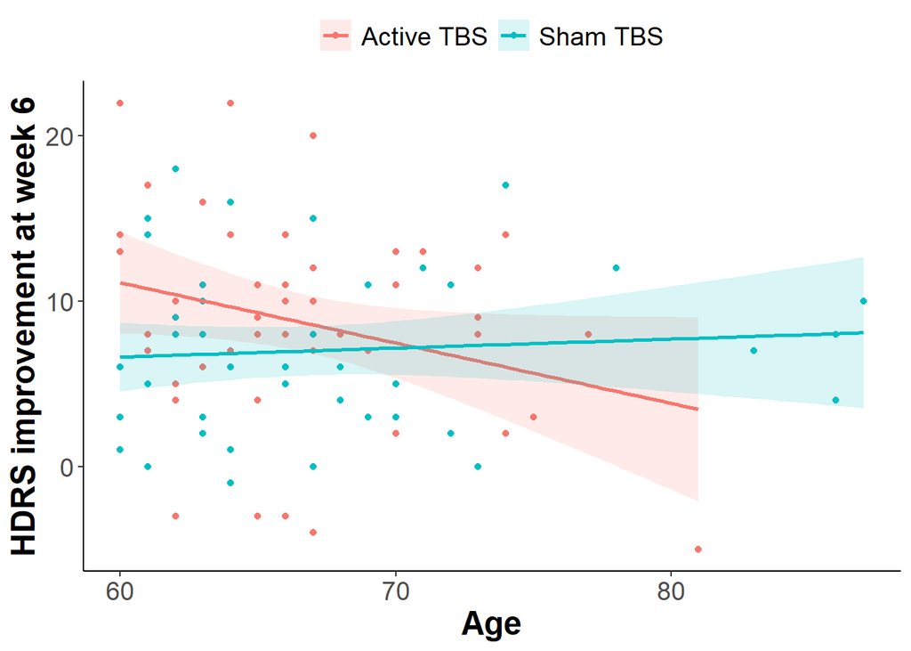

Psychotherapy at week 12

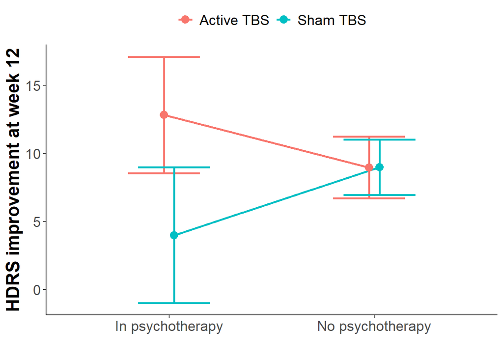

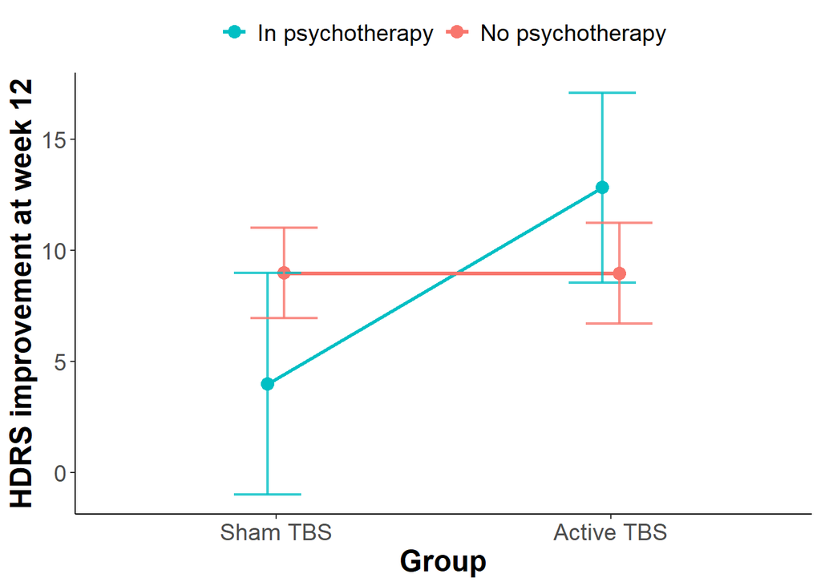

## 6.2 Predicting HDRS response

| Predictor | Main effect Odds ratio | Main effect z | Main effect P | Interaction Odds ratio | Interaction z | Interaction P |
| --- | --- | --- | --- | --- | --- | --- |
| Week 6 |  |  |  |  |  |  |
| Gender | 1.04 | 0.05 | 0.962 | 0.80 | -0.22 | 0.829 |
| Age | 1.00 | -0.09 | 0.932 | 0.98 | -0.28 | 0.778 |
| Ethnicity (white/non-white) | 0.28 | -1.83 | 0.067 | 3.42 | 1.03 | 0.302 |
| Years of education | 1.01 | 0.08 | 0.937 | 1.13 | 1.19 | 0.233 |
| Unemployed (yes/no) | 0.47 | -0.67 | 0.506 | 1.06 | 0.04 | 0.970 |
| Wage (low/high) | 0.88 | -0.19 | 0.852 | 0.40 | -0.99 | 0.323 |
| Relationship (yes/no) | 0.92 | -0.11 | 0.909 | 2.08 | 0.79 | 0.427 |
| Phystical activity (low/high) | 0.81 | -0.24 | 0.814 | 2.10 | 0.63 | 0.532 |
| Hypertension | 5.31 | 2.22 | 0.026 | 0.25 | -1.43 | 0.152 |
| Duration of current episode | 1.00 | 0.02 | 0.987 | 1.00 | 0.07 | 0.947 |
| Refractory depression (yes/no) | 0.64 | -0.56 | 0.578 | 1.13 | 0.12 | 0.905 |
| Current benzodiazepine use (yes/no) | 0.26 | -1.16 | 0.245 | 9.12 | 1.47 | 0.142 |
| Currently in psychotherapy (yes/no) | 0.51 | -0.77 | 0.440 | 10.60 | 1.88 | 0.060 |
| No. failed AD trials in lifetime | 1.03 | 0.21 | 0.837 | 0.84 | -0.70 | 0.487 |
| Onset age of MDD * | 1.01 | 0.45 | 0.653 | 0.96 | -1.09 | 0.274 |
| No. previous depressive episodes * | 0.96 | -0.27 | 0.788 | 1.01 | 0.04 | 0.967 |
| Week 12 |  |  |  |  |  |  |
| Gender | 1.33 | 0.40 | 0.692 | 0.29 | -1.26 | 0.209 |
| Age | 1.01 | 0.28 | 0.782 | 0.98 | -0.28 | 0.778 |
| Ethnicity (white/non-white) | 0.45 | -1.13 | 0.260 | 11.28 | 1.78 | 0.075 |
| Years of education | 0.96 | -0.71 | 0.476 | 1.11 | 1.05 | 0.295 |
| Unemployed (yes/no) | 0.36 | -0.90 | 0.370 | 0.77 | -0.16 | 0.873 |
| Wage (low/high) | 0.71 | -0.49 | 0.623 | 0.86 | -0.17 | 0.862 |
| Relationship (yes/no) | 0.65 | -0.62 | 0.538 | 2.21 | 0.87 | 0.385 |
| Phystical activity (low/high) | 0.49 | -0.83 | 0.406 | 2.14 | 0.69 | 0.493 |
| Hypertension | 2.53 | 1.37 | 0.171 | 0.48 | -0.81 | 0.417 |
| Duration of current episode | 0.94 | -1.46 | 0.145 | 1.06 | 1.24 | 0.215 |
| Refractory depression (yes/no) | 0.25 | -1.57 | 0.115 | 5.29 | 1.52 | 0.129 |
| Current benzodiazepine use (yes/no) | 0.29 | -1.06 | 0.291 | 4.41 | 0.98 | 0.328 |
| Currently in psychotherapy (yes/no) | 0.24 | -1.27 | 0.202 | 8.38 | 1.46 | 0.144 |
| No. failed AD trials in lifetime | 0.87 | -0.83 | 0.407 | 1.35 | 1.15 | 0.251 |
| Onset age of MDD * | 1.02 | 1.09 | 0.276 | 0.97 | -0.82 | 0.414 |
| No. previous depressive episodes * | 0.89 | -0.71 | 0.478 | 1.06 | 0.31 | 0.753 |

*Note:* (*) indicates that data from the HERAH system is missing (33 of 108 patients).